# Assignment

tawaku

2020/12/8

# Prediction for the Weight Lifting Exercise.

## Overview

In this assignment, we built the model to predict how well the excercise is done based on data from accelerometers on the belt, forearm, arm, and dumbell of 6 participants. They were asked to perform barbell lifts correctly and incorrectly in 5 different ways.

## Analysis

Load libraries to be used in this analysis.

Read dumbbell exercise data and replace invalid data to ‘NA’.

```r
data <- read.csv('data/pml-training.csv', na.strings = c('', 'NA', '#DIV/0!'))
quiz <- read.csv('data/pml-testing.csv', na.strings = c('', 'NA', '#DIV/0!'))
```

Find columns that have missing data. Remove columns whose 90% of data is missing.

```r
set.seed(1234)
data %>% sample_n(size = 1000) %>% vis_miss()
```

[figure not shown]

```r
na_count <- apply(data, 2, function(x){ sum(is.na(x)) })
label <- names(na_count[na_count < 0.9 * length(data)])

data <- data %>% select(any_of(label))
quiz <- quiz %>% select(any_of(label))
```

Remove columns that are not related to classe for prediction.

```r
label <- label[!(label %in%
  c(
    'X', 'user_name',
    'raw_timestamp_part_1', 'raw_timestamp_part_2',
    'cvtd_timestamp', 'new_window', 'num_window'
  )
)]

data <- data %>% select(any_of(label))
quiz <- quiz %>% select(any_of(label))
```

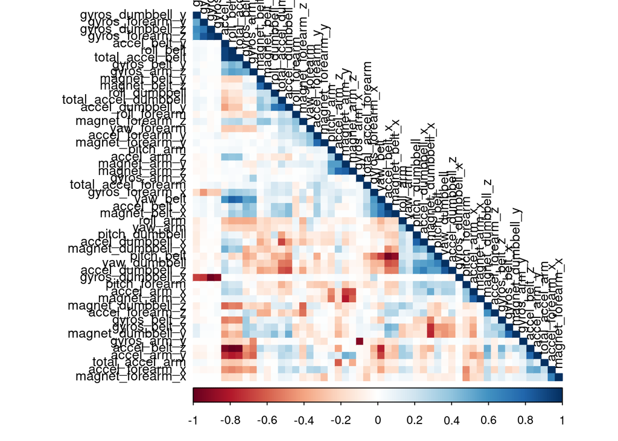

```r
cor_matrix <- cor(data[!names(data) == 'classe'])
corrplot(
  cor_matrix,
  method = 'color',
  type = 'lower',
  order = 'hclust',
  tl.cex = .90,
  tl.col = 'black'
)
```

```r
low_cor_index <- findCorrelation(cor_matrix, cutoff = .70, exact = TRUE)

data <- data %>% select(c(label[low_cor_index], 'classe'))
quiz <- quiz %>% select(label[low_cor_index])
```

Review cleaned data.

```r
summary(data)
```

```
##   accel_belt_z       roll_belt       accel_belt_y     accel_arm_y
##  Min.   :-275.00   Min.   :-28.90   Min.   :-69.00   Min.   :-318.0
##  1st Qu.:-162.00   1st Qu.:  1.10   1st Qu.:  3.00   1st Qu.: -54.0
##  Median :-152.00   Median :113.00   Median : 35.00   Median :  14.0
##  Mean   : -72.59   Mean   : 64.41   Mean   : 30.15   Mean   :  32.6
##  3rd Qu.:  27.00   3rd Qu.:123.00   3rd Qu.: 61.00   3rd Qu.: 139.0
##  Max.   : 105.00   Max.   :162.00   Max.   :164.00   Max.   : 308.0
##  total_accel_belt    yaw_belt       accel_dumbbell_z   accel_belt_x
##  Min.   : 0.00    Min.   :-180.00   Min.   :-334.00   Min.   :-120.000
##  1st Qu.: 3.00    1st Qu.: -88.30   1st Qu.:-142.00   1st Qu.: -21.000
##  Median :17.00    Median : -13.00   Median :  -1.00   Median : -15.000
##  Mean   :11.31    Mean   : -11.21   Mean   : -38.32   Mean   :  -5.595
##  3rd Qu.:18.00    3rd Qu.:  12.90   3rd Qu.:  38.00   3rd Qu.:  -5.000
##  Max.   :29.00    Max.   : 179.00   Max.   : 318.00   Max.   :  85.000
##    pitch_belt       magnet_dumbbell_x accel_dumbbell_y  magnet_dumbbell_y
##  Min.   :-55.8000   Min.   :-643.0    Min.   :-189.00   Min.   :-3600
##  1st Qu.:  1.7600   1st Qu.:-535.0    1st Qu.:  -8.00   1st Qu.:  231
##  Median :  5.2800   Median :-479.0    Median :  41.50   Median :  311
##  Mean   :  0.3053   Mean   :-328.5    Mean   :  52.63   Mean   :  221
##  3rd Qu.: 14.9000   3rd Qu.:-304.0    3rd Qu.: 111.00   3rd Qu.:  390
##  Max.   : 60.3000   Max.   : 592.0    Max.   : 315.00   Max.   :  633
##   accel_arm_x      accel_dumbbell_x   accel_arm_z       magnet_arm_y
##  Min.   :-404.00   Min.   :-419.00   Min.   :-636.00   Min.   :-392.0
##  1st Qu.:-242.00   1st Qu.: -50.00   1st Qu.:-143.00   1st Qu.:  -9.0
##  Median : -44.00   Median :  -8.00   Median : -47.00   Median : 202.0
##  Mean   : -60.24   Mean   : -28.62   Mean   : -71.25   Mean   : 156.6
##  3rd Qu.:  84.00   3rd Qu.:  11.00   3rd Qu.:  23.00   3rd Qu.: 323.0
##  Max.   : 437.00   Max.   : 235.00   Max.   : 292.00   Max.   : 583.0
##  magnet_belt_z    accel_forearm_y  gyros_forearm_z    gyros_dumbbell_x
##  Min.   :-623.0   Min.   :-632.0   Min.   : -8.0900   Min.   :-204.0000
##  1st Qu.:-375.0   1st Qu.:  57.0   1st Qu.: -0.1800   1st Qu.:  -0.0300
##  Median :-320.0   Median : 201.0   Median :  0.0800   Median :   0.1300
##  Mean   :-345.5   Mean   : 163.7   Mean   :  0.1512   Mean   :   0.1611
##  3rd Qu.:-306.0   3rd Qu.: 312.0   3rd Qu.:  0.4900   3rd Qu.:   0.3500
##  Max.   : 293.0   Max.   : 923.0   Max.   :231.0000   Max.   :   2.2200
##  gyros_dumbbell_z   gyros_arm_x       classe
##  Min.   : -2.380   Min.   :-6.37000   A:5580
##  1st Qu.: -0.310   1st Qu.:-1.33000   B:3797
##  Median : -0.130   Median : 0.08000   C:3422
##  Mean   : -0.129   Mean   : 0.04277   D:3216
##  3rd Qu.:  0.030   3rd Qu.: 1.57000   E:3607
##  Max.   :317.000   Max.   : 4.87000
```

Separate data to training/testing for cross validation.

```r
inTrain <- createDataPartition(y = data$classe, p = 0.75, list = FALSE)
training <- data[inTrain,]
testing <- data[-inTrain,]
```

Train the model with decision tree. Calculate the accuracy of this model and it’s 0.676.

```r
rp_model <- rpart(classe ~ ., data = training, method = 'class')
rp_pred <- predict(rp_model, testing, type = 'class')

(rp_cm <- table(rp_pred, testing$classe))
```

```
##
## rp_pred    A    B    C    D    E
##       A 1127  151  136  108   73
##       B   45  568   59   32   38
##       C   72   92  547  134  126
##       D  104  111  113  497   86
##       E   47   27    0   33  578
```

```r
sum(diag(rp_cm))/sum(rp_cm)
```

```
## [1] 0.6763866
```

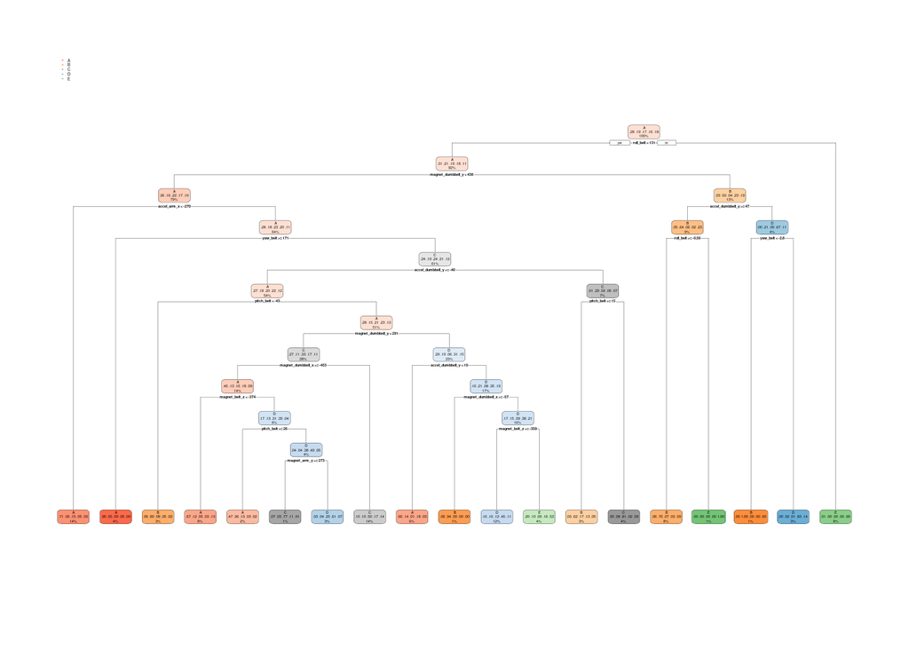

```r
rpart.plot(rp_model)
```

Train the model with random forest. Calculate the accuracy of this model and it’s 0.987. Based on the plot, important variables are roll_belt, yaw_belt and pitch_belt.

```r
rf_model <- randomForest(
    x = training[names(training) != 'classe'],
    y = training$classe,
    xtest = testing[names(testing) != 'classe'],
    ytest = testing$classe,
    keep.forest = TRUE
)
rf_model$confusion
```

```
##      A    B    C    D    E class.error
## A 4165    7    6    6    1 0.004778973
## B   32 2795   20    1    0 0.018609551
## C    9   24 2526    8    0 0.015971952
## D    5    0   35 2369    3 0.017827529
## E    0    8    4    9 2685 0.007760532
```

```r
sum(diag(rf_model$confusion)/sum(rf_model$confusion))
```

```
## [1] 0.9879016
```

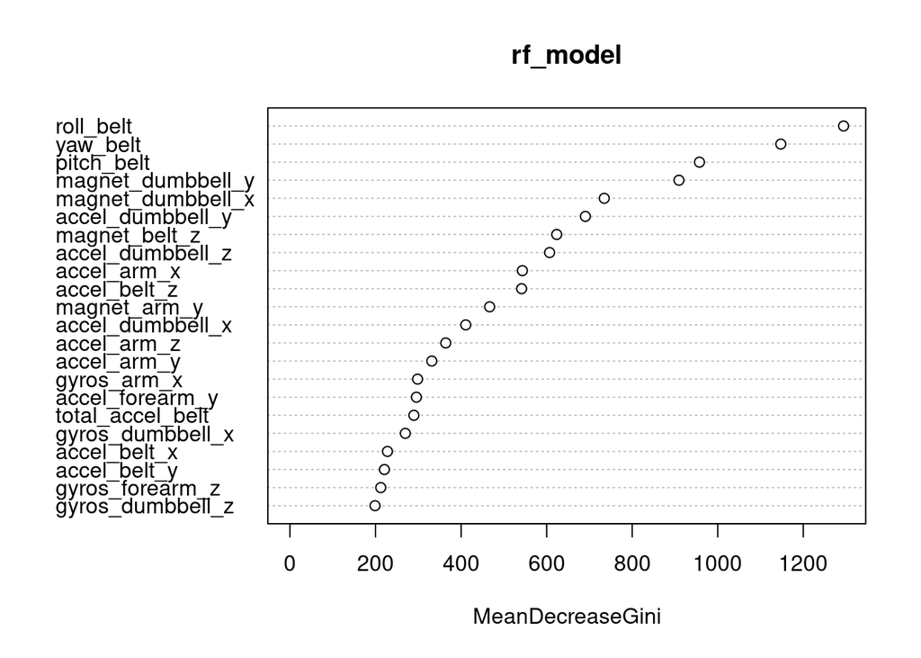

```r
varImpPlot(rf_model)
```

Check if PCA will improve the accuracy of model. PC1 ~ PC11 explain about .975.

```r
pca_data <- prcomp(data[names(data) != 'classe'], center = TRUE, scale = TRUE)
summary(pca_data)
```

```
## Importance of components:
##                           PC1    PC2    PC3    PC4     PC5     PC6     PC7
## Standard deviation     2.4569 2.0725 1.6992 1.5067 1.15637 1.10860 1.01339
## Proportion of Variance 0.2744 0.1953 0.1312 0.1032 0.06078 0.05586 0.04668
## Cumulative Proportion  0.2744 0.4696 0.6008 0.7040 0.76482 0.82068 0.86736
##                            PC8     PC9    PC10    PC11    PC12   PC13    PC14
## Standard deviation     0.89805 0.82730 0.70593 0.61908 0.42376 0.2891 0.25520
## Proportion of Variance 0.03666 0.03111 0.02265 0.01742 0.00816 0.0038 0.00296
## Cumulative Proportion  0.90402 0.93513 0.95778 0.97520 0.98337 0.9872 0.99013
##                           PC15    PC16   PC17    PC18    PC19    PC20    PC21
## Standard deviation     0.23418 0.21108 0.1815 0.16648 0.16085 0.13056 0.10415
## Proportion of Variance 0.00249 0.00203 0.0015 0.00126 0.00118 0.00077 0.00049
## Cumulative Proportion  0.99262 0.99464 0.9961 0.99740 0.99858 0.99935 0.99984
##                           PC22
## Standard deviation     0.05850
## Proportion of Variance 0.00016
## Cumulative Proportion  1.00000
```

Built random forest with PCA data. PCA data doesn’t improve the accuracy.

```r
pca_data <- data.frame(classe = data$classe, pca_data$x)
pca_data <- pca_data[,1:11]

inTrain <- createDataPartition(y = pca_data$classe, p = 0.75, list = FALSE)
pca_training <- pca_data[inTrain,]
pca_testing <- pca_data[-inTrain,]

pca_rf_model <- randomForest(
    x = pca_training[names(pca_training) != 'classe'],
    y = pca_training$classe,
    xtest = pca_testing[names(pca_testing) != 'classe'],
    ytest = pca_testing$classe,
    keep.forest = TRUE
)

pca_rf_model$confusion
```

```
##      A    B    C    D    E class.error
## A 4004   41   58   71   11  0.04324970
## B  119 2593   86   39   11  0.08953652
## C   60   69 2386   44    8  0.07051032
## D   72   20  135 2166   19  0.10199005
## E   20   32   35   31 2588  0.04360680
```

```r
sum(diag(pca_rf_model$confusion)/sum(pca_rf_model$confusion))
```

```
## [1] 0.9333248
```

## Conclusion

RandomForest with raw dataset has highest accuracy among models we built to predict how well the excercise is done. Predict quiz data with the model.

```r
predict(rf_model, newdata = quiz)
```

```
##  1  2  3  4  5  6  7  8  9 10 11 12 13 14 15 16 17 18 19 20
##  B  A  B  A  A  E  D  B  A  A  B  C  B  A  E  E  A  B  B  B
## Levels: A B C D E
```